# Development and validation of the FAI scale

Diagnosis Category as Criterion Variable

Author

Corrado Caudek

Published

December 11, 2024

## Background

This study aims to develop a psychological scale to differentiate between family caregivers of children with chronic illnesses based on their coping abilities. This scale will be used to identify caregivers who may benefit from additional support or interventions.

## Objective

In this analysis, the diagnosis category (i.e., Lieve, Grave, Moderata, Molto grave) will be used as the criterion variable in a predictive model. The purpose is to evaluate the classification ability of the FAI scales.

## Load packages and options

```r
if (!requireNamespace("pacman")) install.packages("pacman")

pacman::p_load(
  here, tidyverse, TAM, mirt, lavaan, mokken, psych, semTools,
  ids, pROC, nnet, caret, ROSE, DMwR, recipes, themis, randomForest
)

# Disable significance stars globally
options(show.signif.stars = FALSE)
```

## Import the Data

```r
# Import RedCap data ------------------------------------------------------

setwd("~/_repositories/meyer_fai/scripts/redcap")

# This will load the necessary libreries
source(here::here("scripts", "redcap", "_targets.R"))

# Read cleaned RedCap data
temp <- tar_read(fai_clean_complete)
# Some cases are empty and will be ignored: 12 18 76 81 152 182 193 202
temp1 <- temp[-c(12, 18, 76, 81, 152, 182, 193, 202), ]
# Remove outlier found with the performance package
fai_clean_complete <- temp1[-92, ]
rm(temp, temp1)

fai <- fai_clean_complete |>
  dplyr::select(
    fai_child_charact, fai_caregiving, fai_cure, fai_intrapsych,
    fai_support, fai_hyper, quanti_fratelli, sesso, nome_malattia,
    eta_pz, legge_104
  ) |>
   dplyr::rename(
     fai_child_char = fai_child_charact,
     fai_caregiving = fai_caregiving,
     fai_percz_cure = fai_cure,
     fai_intra_psyc = fai_intrapsych,
     fai_soc_fam_sp = fai_support,
     fai_hyper_prot = fai_hyper
     #eta_madre = erta_madre
   )
```

Determine severity level:

```r
fai <- fai |>
  mutate(
    nome_malattia_raggruppato = case_when(
      # Molto grave: malattie con alto rischio di morte o che
      # richiedono trattamenti intensivi
      nome_malattia %in% c(
        "glioma", "LLA", "linfoma anaplastico", "Leucemia mieloide",
        "fibrosi cistica", "Pinealoblastoma",
        "tumore glioneurale leptomeningeale diffuso"
        ) ~ "Molto grave",

      # Grave: malattie croniche, con impatto significativo sulla
      # qualità della vita
      nome_malattia %in% c(
        "Epilessia", "sindrome di charge", "Distrofia muscolare",
        "Neurofibromatosi", "diabete di tipo 1", "artrite romatoide",
        "RCU", "emofilia"
        ) ~ "Grave",

      # Moderata: malattie con impatto moderato, trattabili ma non
      # trascurabili
      nome_malattia %in% c(
        "asma", "Emicrania", "dermatite atopica", "ipospadia",
        "ipotonia muscolare", "Blefaro chetato congiuntivite"
        ) ~ "Moderata",

      # Lieve: condizioni gestibili con trattamenti standard e
      # basso impatto funzionale
      TRUE ~ "Lieve"
    )
  )

fai$nome_malattia_raggruppato <- factor(fai$nome_malattia_raggruppato)
fai$nome_malattia_raggruppato <-
  relevel(fai$nome_malattia_raggruppato, ref = "Lieve")

fai$nome_malattia <- NULL
```

```r
table(fai$nome_malattia_raggruppato)
```

```
      Lieve       Grave    Moderata Molto grave
        181           9           7           7
```

## Address Class Imbalance

Given the imbalance in severity levels, apply techniques to ensure the model learns effectively from minority classes.

Oversampling with Recipes Use recipes to balance the dataset by oversampling:

```r
set.seed(123)

# Create an upsampling recipe
recipe_obj <- recipe(nome_malattia_raggruppato ~ ., data = fai) %>%
  step_upsample(nome_malattia_raggruppato, over_ratio = 1)

# Prepare balanced data
balanced_fai <- prep(recipe_obj) %>% juice()
table(balanced_fai$nome_malattia_raggruppato)
```

```
      Lieve       Grave    Moderata Molto grave
        181         181         181         181
```

### Build Models

1. Multinomial Logistic Regression This model is interpretable and works well for multiclass classification.

```r
# Fit multinomial logistic regression
set.seed(123)
fm <- multinom(
  nome_malattia_raggruppato ~ fai_child_char + fai_caregiving +
    fai_percz_cure +
    fai_intra_psyc + fai_soc_fam_sp + fai_hyper_prot + sesso + eta_pz +
    quanti_fratelli + legge_104,
  data = balanced_fai
)
# Model summary
summary(fm)
```

```
Call:
multinom(formula = nome_malattia_raggruppato ~ fai_child_char +
    fai_caregiving + fai_percz_cure + fai_intra_psyc + fai_soc_fam_sp +
    fai_hyper_prot + sesso + eta_pz + quanti_fratelli + legge_104,
    data = balanced_fai)

Coefficients:
            (Intercept) fai_child_char fai_caregiving fai_percz_cure
Grave        -10.024630      0.1614103      0.6962088      0.3699323
Moderata      -8.554701     -0.1976772      0.8700737     -0.1676825
Molto grave  -36.443758     -0.5969955      3.0783300      2.3269358
            fai_intra_psyc fai_soc_fam_sp fai_hyper_prot sessofemale
Grave          -0.08232539     0.06010216     -0.1633662   0.7569541
Moderata        0.42843845     0.21820070      0.1207470   0.2896206
Molto grave    -1.99518284    -0.57072848     -1.6863261  -7.3950576
                 eta_pz quanti_fratelli legge_1041
Grave       -0.04148433       0.7752675  -23.53892
Moderata    -0.28953617       1.4827073  -56.12895
Molto grave  0.38892920       3.8476020   11.59118

Std. Errors:
            (Intercept) fai_child_char fai_caregiving fai_percz_cure
Grave          1.599113     0.06074493     0.08944916     0.04974934
Moderata       1.479982     0.08300838     0.10011118     0.03375205
Molto grave   10.617402     0.23886260     0.52547432     0.50804244
            fai_intra_psyc fai_soc_fam_sp fai_hyper_prot sessofemale     eta_pz
Grave           0.06863402     0.07341687     0.05002502   0.3783648 0.02715316
Moderata        0.07984509     0.07253733     0.04964101   0.3260529 0.04920225
Molto grave     0.55270310     0.35041535     0.49974600   2.5494422 0.10538153
            quanti_fratelli   legge_1041
Grave             0.2304383 5.608952e-09
Moderata          0.2359183 4.840865e-13
Molto grave       1.3178264 1.380437e+01

Residual Deviance: 709.1123
AIC: 775.1123
```

### Fit Random Forest

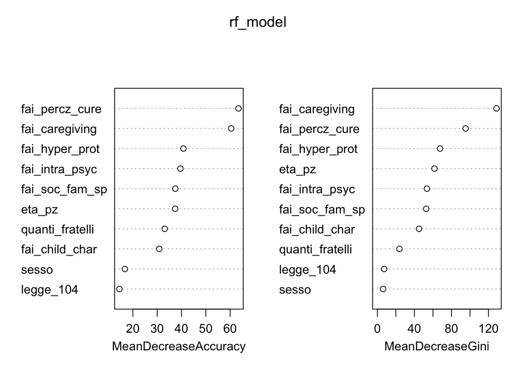

```r
set.seed(123)
rf_model <- randomForest(
  nome_malattia_raggruppato ~ fai_child_char + fai_caregiving +
    fai_percz_cure +
    fai_intra_psyc + fai_soc_fam_sp + fai_hyper_prot + sesso +
    eta_pz +
    quanti_fratelli + legge_104,
  data = balanced_fai,
  ntree = 500,
  importance = TRUE
)

# Variable importance
varImpPlot(rf_model)
```

### XGBoost

```r
library(xgboost)

# Prepare data for XGBoost
train_matrix <- model.matrix(nome_malattia_raggruppato ~ ., data = balanced_fai)[, -1]
train_labels <- as.numeric(balanced_fai$nome_malattia_raggruppato) - 1

# Fit XGBoost
set.seed(123)
xgb_model <- xgboost(
  data = as.matrix(train_matrix),
  label = train_labels,
  objective = "multi:softmax",
  num_class = length(unique(fai$nome_malattia_raggruppato)),
  nrounds = 100,
  eta = 0.3,
  max_depth = 6,
  eval_metric = "mlogloss"
)
```

### Evaluate Model Performance

Predictions on Test Data Use stratified train-test splitting to ensure balanced evaluation:

```r
# Create train-test split
set.seed(123)
train_index <- createDataPartition(
  fai$nome_malattia_raggruppato, p = 0.7, list = FALSE)
train <- fai[train_index, ]
test <- fai[-train_index, ]

# Predict and evaluate for Random Forest
test_predictions_rf <- predict(rf_model, newdata = test)
conf_matrix_rf <- confusionMatrix(
  data = test_predictions_rf,
  reference = test$nome_malattia_raggruppato
)
print(conf_matrix_rf)
```

```
Confusion Matrix and Statistics

             Reference
Prediction    Lieve Grave Moderata Molto grave
  Lieve          54     0        0           0
  Grave           0     2        0           0
  Moderata        0     0        2           0
  Molto grave     0     0        0           2

Overall Statistics

               Accuracy : 1
                 95% CI : (0.9404, 1)
    No Information Rate : 0.9
    P-Value [Acc > NIR] : 0.001797

                  Kappa : 1

 Mcnemar's Test P-Value : NA

Statistics by Class:

                     Class: Lieve Class: Grave Class: Moderata
Sensitivity                   1.0      1.00000         1.00000
Specificity                   1.0      1.00000         1.00000
Pos Pred Value                1.0      1.00000         1.00000
Neg Pred Value                1.0      1.00000         1.00000
Prevalence                    0.9      0.03333         0.03333
Detection Rate                0.9      0.03333         0.03333
Detection Prevalence          0.9      0.03333         0.03333
Balanced Accuracy             1.0      1.00000         1.00000
                     Class: Molto grave
Sensitivity                     1.00000
Specificity                     1.00000
Pos Pred Value                  1.00000
Neg Pred Value                  1.00000
Prevalence                      0.03333
Detection Rate                  0.03333
Detection Prevalence            0.03333
Balanced Accuracy               1.00000
```

Metrics:

- Accuracy: Percentage of correct predictions.
- Precision, Recall, F1-score: Assess performance for each class.
- Confusion Matrix: Evaluate class-specific performance.

```r
conf_matrix_rf$byClass  # Class-specific metrics
```

```
                   Sensitivity Specificity Pos Pred Value Neg Pred Value
Class: Lieve                 1           1              1              1
Class: Grave                 1           1              1              1
Class: Moderata              1           1              1              1
Class: Molto grave           1           1              1              1
                   Precision Recall F1 Prevalence Detection Rate
Class: Lieve               1      1  1 0.90000000     0.90000000
Class: Grave               1      1  1 0.03333333     0.03333333
Class: Moderata            1      1  1 0.03333333     0.03333333
Class: Molto grave         1      1  1 0.03333333     0.03333333
                   Detection Prevalence Balanced Accuracy
Class: Lieve                 0.90000000                 1
Class: Grave                 0.03333333                 1
Class: Moderata              0.03333333                 1
Class: Molto grave           0.03333333                 1
```

```r
conf_matrix_rf$overall  # Overall metrics
```

```
      Accuracy          Kappa  AccuracyLower  AccuracyUpper   AccuracyNull
    1.00000000     1.00000000     0.94037051     1.00000000     0.90000000
AccuracyPValue  McnemarPValue
    0.00179701            NaN
```

### Cross-Validation

Use cross-validation to ensure robustness:

```r
set.seed(123)
train_control <- trainControl(method = "cv", number = 10)

# Train Random Forest with cross-validation
cv_model <- train(
  nome_malattia_raggruppato ~ .,
  data = fai,
  method = "rf",
  trControl = train_control
)
print(cv_model)
```

```
Random Forest

204 samples
 10 predictor
  4 classes: 'Lieve', 'Grave', 'Moderata', 'Molto grave'

No pre-processing
Resampling: Cross-Validated (10 fold)
Summary of sample sizes: 184, 184, 183, 183, 184, 184, ...
Resampling results across tuning parameters:

  mtry  Accuracy   Kappa
   2    0.8826190  -0.005263158
   6    0.8826190   0.029788388
  10    0.8828571   0.110950669

Accuracy was used to select the optimal model using the largest value.
The final value used for the model was mtry = 10.
```

## Bibliography

```r
# Create the severity variable based on `nome_malattia`
fai_clean_complete <- fai_clean_complete %>%
  mutate(
    nome_malattia_raggruppato = case_when(
      # Molto grave: severe conditions with high mortality risk
      nome_malattia %in% c(
        "glioma", "LLA", "linfoma anaplastico", "Leucemia mieloide",
        "fibrosi cistica", "Pinealoblastoma",
        "tumore glioneurale leptomeningeale diffuso"
      ) ~ "Molto grave",

      # Grave: chronic illnesses significantly impacting quality of life
      nome_malattia %in% c(
        "Epilessia", "sindrome di charge", "Distrofia muscolare",
        "Neurofibromatosi", "diabete di tipo 1", "artrite romatoide",
        "RCU", "emofilia"
      ) ~ "Grave",

      # Moderata: moderate conditions that are treatable but impactful
      nome_malattia %in% c(
        "asma", "Emicrania", "dermatite atopica", "ipospadia",
        "ipotonia muscolare", "Blefaro chetato congiuntivite"
      ) ~ "Moderata",

      # Lieve: mild conditions manageable with standard treatments
      TRUE ~ "Lieve"
    )
  ) %>%
  mutate(
    nome_malattia_raggruppato = factor(nome_malattia_raggruppato, levels = c("Lieve", "Moderata", "Grave", "Molto grave"))
  ) %>%
  dplyr::select(-nome_malattia)  # Remove the original disease name variable
```

```r
table(fai_clean_complete$nome_malattia_raggruppato)
```

```
      Lieve    Moderata       Grave Molto grave
        181           7           9           7
```

```r
fai_clean_complete <- fai_clean_complete %>%
  mutate(across(starts_with("fai"), scale))
```

```r
library(recipes)

set.seed(123)
# Upsampling recipe
recipe_obj <- recipe(
  nome_malattia_raggruppato ~ ., data = fai_clean_complete) %>%
  step_upsample(nome_malattia_raggruppato, over_ratio = 1)  # Balance classes

# Prepare the balanced dataset
balanced_data <- prep(recipe_obj) %>% juice()
table(balanced_data$nome_malattia_raggruppato)
```

```
      Lieve    Moderata       Grave Molto grave
        181         181         181         181
```

```r
set.seed(123)
train_index <- createDataPartition(
  balanced_data$nome_malattia_raggruppato, p = 0.7, list = FALSE)
train_data <- balanced_data[train_index, ]
test_data <- balanced_data[-train_index, ]
```

```r
# Fit multinomial logistic regression
multinom_model <- multinom(
  nome_malattia_raggruppato ~ fai_child_charact + fai_caregiving +
    fai_cure + fai_intrapsych + fai_support + fai_hyper +
    sesso + eta_pz + quanti_fratelli + legge_104,
  data = train_data
)
# Model summary
summary(multinom_model)
```

```
Call:
multinom(formula = nome_malattia_raggruppato ~ fai_child_charact +
    fai_caregiving + fai_cure + fai_intrapsych + fai_support +
    fai_hyper + sesso + eta_pz + quanti_fratelli + legge_104,
    data = train_data)

Coefficients:
             (Intercept) fai_child_charact fai_caregiving  fai_cure
Moderata       0.5891429        -0.5156616       3.086308 -1.227647
Grave         -2.2699139         0.2607646       2.922437  2.591188
Molto grave -129.8692640       -22.8589227      32.961386 73.496993
            fai_intrapsych fai_support  fai_hyper sessofemale      eta_pz
Moderata         1.9178811   0.2799642  0.5482527  -0.1177085 -0.31079802
Grave            0.1060545  -0.1806292 -0.7632672   0.8067602 -0.03748393
Molto grave    -37.0918755 -19.7492278 -0.8282566 -49.3415418  0.98254369
            quanti_fratelli legge_1041
Moderata          1.2884181 -329.48617
Grave             0.5373602  -92.51665
Molto grave      15.5728212   67.12726

Std. Errors:
            (Intercept) fai_child_charact fai_caregiving  fai_cure
Moderata      0.4714855         0.3164800      0.4347797 0.2562332
Grave         0.5320775         0.2447721      0.3938473 0.3942703
Molto grave   9.2807990         2.7369521      2.7124578 5.8268837
            fai_intrapsych fai_support fai_hyper sessofemale     eta_pz
Moderata         0.3304772   0.2486595 0.2347095   0.4089465 0.05917558
Grave            0.2662406   0.2622261 0.2474826   0.4664709 0.03315129
Molto grave      2.1267533   2.8751146 2.9139629  49.9954795 0.07701539
            quanti_fratelli   legge_1041
Moderata          0.2611359 4.716382e-13
Grave             0.2614088          NaN
Molto grave       5.6521846 6.421391e+00

Residual Deviance: 464.6572
AIC: 530.6572
```

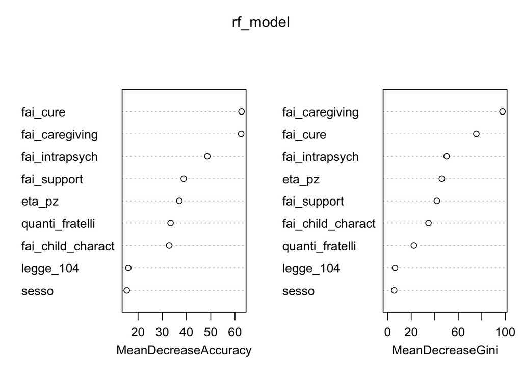

```r
# Fit Random Forest
rf_model <- randomForest(
  nome_malattia_raggruppato ~
    fai_child_charact + fai_caregiving +
    fai_cure + fai_intrapsych + fai_support + sesso + eta_pz +
    quanti_fratelli + legge_104,
  data = train_data,
  ntree = 500,
  importance = TRUE
)

# Variable importance
varImpPlot(rf_model)
```

```r
# Predict using Random Forest
test_predictions_rf <- predict(rf_model, newdata = test_data)

# Evaluate performance
conf_matrix <- confusionMatrix(
  data = test_predictions_rf,
  reference = test_data$nome_malattia_raggruppato
)
print(conf_matrix)
```

```
Confusion Matrix and Statistics

             Reference
Prediction    Lieve Moderata Grave Molto grave
  Lieve          53        0     0           0
  Moderata        0       54     0           0
  Grave           1        0    54           0
  Molto grave     0        0     0          54

Overall Statistics

               Accuracy : 0.9954
                 95% CI : (0.9745, 0.9999)
    No Information Rate : 0.25
    P-Value [Acc > NIR] : < 2.2e-16

                  Kappa : 0.9938

 Mcnemar's Test P-Value : NA

Statistics by Class:

                     Class: Lieve Class: Moderata Class: Grave
Sensitivity                0.9815            1.00       1.0000
Specificity                1.0000            1.00       0.9938
Pos Pred Value             1.0000            1.00       0.9818
Neg Pred Value             0.9939            1.00       1.0000
Prevalence                 0.2500            0.25       0.2500
Detection Rate             0.2454            0.25       0.2500
Detection Prevalence       0.2454            0.25       0.2546
Balanced Accuracy          0.9907            1.00       0.9969
                     Class: Molto grave
Sensitivity                        1.00
Specificity                        1.00
Pos Pred Value                     1.00
Neg Pred Value                     1.00
Prevalence                         0.25
Detection Rate                     0.25
Detection Prevalence               0.25
Balanced Accuracy                  1.00
```

```r
conf_matrix$byClass  # Sensitivity, specificity, and F1-score for each class
```

```
                   Sensitivity Specificity Pos Pred Value Neg Pred Value
Class: Lieve         0.9814815   1.0000000      1.0000000       0.993865
Class: Moderata      1.0000000   1.0000000      1.0000000       1.000000
Class: Grave         1.0000000   0.9938272      0.9818182       1.000000
Class: Molto grave   1.0000000   1.0000000      1.0000000       1.000000
                   Precision    Recall        F1 Prevalence Detection Rate
Class: Lieve       1.0000000 0.9814815 0.9906542       0.25      0.2453704
Class: Moderata    1.0000000 1.0000000 1.0000000       0.25      0.2500000
Class: Grave       0.9818182 1.0000000 0.9908257       0.25      0.2500000
Class: Molto grave 1.0000000 1.0000000 1.0000000       0.25      0.2500000
                   Detection Prevalence Balanced Accuracy
Class: Lieve                  0.2453704         0.9907407
Class: Moderata               0.2500000         1.0000000
Class: Grave                  0.2546296         0.9969136
Class: Molto grave            0.2500000         1.0000000
```